# Why use R?

2020-11-02 08:46:00

## Packages

```r
library(tidyverse)
library(nlme)
```

## Data, methods and logic

*[Brown, Kaiser & Allison, PNAS, 2018](https://doi.org/10.1073/pnas.1708279115)*

"…in science, three things matter:

1. the data,
2. the methods used to collect the data […], and
3. **the logic connecting the data and methods to conclusions,**

everything else is a distraction."

## When things go wrong

[figure not shown]

“In one case, a group accidentally used reverse-coded variables, making their conclusions the opposite of what the data supported.”

“In another case, authors received an incomplete dataset because entire categories of data were missed; when corrected, the qualitative conclusions did not change, but the quantitative conclusions changed by a factor of >7”

[Brown, Kaiser & Allison, 2018; PNAS](https://doi.org/10.1073/pnas.1708279115)

## Why we need Reproducible (Open) Science?

- To assess validity of science and methods we need access to data, methods and conclusions
- To learn from choices other researchers made
- To learn from omissions, mistakes or errors
- To prevent publication bias (also negative results will be available in reproducible research)
- To be able to re-use and/or synthesize data (from many and diverse sources)
- To have access to it all!

[Nature Collection on this topic](https://www.nature.com/collections/prbfkwmwvz)

## The *GUI problem*

How would you ‘describe’ the steps of an analysis or creation of a graph when you use *GUI* based software?

*“You can only do this using code, so it is (basically) impossible in a GUI”*

[figure not shown]

*[Graphical User Interface (GUI)…is a form of user interface that allows users to interact with electronic devices through graphical icons and audio indicator such as primary notation, instead of text-based user interfaces, typed command labels or text navigation…](https://en.wikipedia.org/wiki/Graphical_user_interface)

## Programming is essential for Reproducible (Open) Science

- Only programming an analysis (or creation of a graph) records every step
- The script(s) function as a (data) analysis journal
- Code is the logic that connects the data and methods to conclusions
- Learning to use a programming language takes time but pays of at the long run (for all of science)

## Introducing Literate programming

- Literate) programming is a way to connect narratives to data, methods and results
- All scripts in this course are **R Markdown** scripts
- The complete source of the reader is available in Github.com

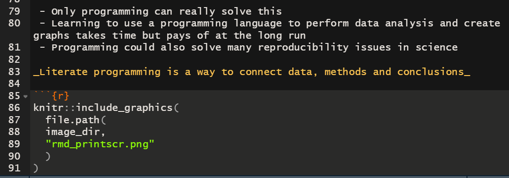

```r
knitr::include_graphics(here::here("images","rmd_printscr.png"))
```

## Why R?

- R is free
- R is Open Source
- R has a huge user-community
- R has many packages
- Many statistical applications (more than SPSS)
- R connects to many other tools (e.g. databases, web servers, Java Script, \(LaTeX\), Stan, Python, and many more)
- R has RStudio as an IDE
- You can find (almost) every example you want on the internet
- R has superb plotting possibilities
- In R we can document the three things that matter in science: *“data, methods and logic connecting them to the conclusions”* …

## What people do with R?

The possibilities and applications are endless: just a few highlights

- Statistical analysis ([Bayesian](https://bookdown.org/ajkurz/Statistical_Rethinking_recoded/) / [Test-driven](https://www.youtube.com/watch?v=FhoYCsZttGc))
- Geo-spatial data ([maps](https://shiny.rstudio.com/gallery/covid19-tracker.html)[`{geocompr}`](https://geocompr.robinlovelace.net/intro.html), [time series](https://ubidi.shinyapps.io/covid19world/))
- AI; Machine Learning / Deep Learning / [Forecasting](https://ubidi.shinyapps.io/covid19world/) / [NLP](https://www.kaggle.com/mdurazob/cord-19-vaccines-networks-and-bibliometrics)
- Visualization; static, [interactive](https://www.gapminder.org/tools/), [dashboards](https://datascience.hu.nl/shiny/r-starters/marc.teunis/corona-dash/)
- [Internet of things](https://www.slideshare.net/SeonghakHong/iot-and-big-data-with-r), sensor data
- [Econometrics](https://www.econometrics-with-r.org/)
- [Text mining](https://www.tidytextmining.com/), network analysis
- [Mathematics](https://en.wikibooks.org/wiki/R_Programming/Mathematics#Basics) / [Big data](https://rviews.rstudio.com/2019/07/17/3-big-data-strategies-for-r/) / Algorithm development
- [Webscraping](https://www.analyticsvidhya.com/blog/2017/03/beginners-guide-on-web-scraping-in-r-using-rvest-with-hands-on-knowledge/)
- [API development](https://www.rplumber.io/)
- {And many more…}

## A short example of Reproducible (Open) Science

Assume we have the following question: “Which of 4 types of chairs takes the least effort to arise from when seated in?” We have the following setup:

- 4 different types of chairs
- 9 different subjects (probably somewhat aged)
- Each subject is required to provide a score (from 6 to 20, 6 being very lightly strenuous, 20 being extremely strenuous) when arising from each of the 4 chairs. There is some ‘wash-out’ time in between the trials. The chair order is randomised.

To analyze this experiment statistically, the model would need to include: the rating score as the **measured (or dependent) variable**, the type of chair as the **experimental factor** and the subject as the **blocking factor**

- If you have 2 screens, now is the moment to expand the screen
- Login to your Rstudio Environment
- Clone the materials from [Github.com](https://github.com/uashogeschoolutrecht/staRters)
- Open the file `..._why_r.Rmd`
- Follow along the demo by running the code
- Details on using RStudio can be found in `..._introrstudio`
- A demo for RStudio details will follow after the case example

## Mixed effects models

A typical analysis method for this type of randomized block design is a so-called ‘multi-level’ or also called ‘mixed-effects’ or ‘hierarchical’ or ‘multilevel’ models. An analysis method much used in clinical or biological scientific practice.

## What do we minimally need, to replicate the science of this experiment?

I will show:

- the data
- an exploratory graph
- a statistical model
- the statistical model results
- a model diagnostic
- some conclusions

In the next few slides, I will hopefully convince you of the power of (literate) programming to communicate such an analysis.

[Example reproduced from: Pinheiro and Bates, 2000, *Mixed-Effects Models in S and S-PLUS*, Springer, New York.](https://cran.r-project.org/web/packages/nlme/index.html)

## The data of the experiment

[Wretenberg, Arborelius & Lindberg, 1993](https://doi.org/10.1080/00140139308967910)

```r
library(nlme)
ergoStool %>% as_tibble()
```

```
## # A tibble: 36 x 3
##    effort Type  Subject
##     <dbl> <fct> <ord>
##  1     12 T1    1
##  2     15 T2    1
##  3     12 T3    1
##  4     10 T4    1
##  5     10 T1    2
##  6     14 T2    2
##  7     13 T3    2
##  8     12 T4    2
##  9      7 T1    3
## 10     14 T2    3
## # … with 26 more rows
```

## An exploratory graph

I like the initial plot that I create of a new dataset to contain **ALL** the data. Here, I combine the scatter plot with a boxplot to get a feel for the spread and the group means. Mind the ordering on the x-axis, which is set according the mean value of the `effort` variable.

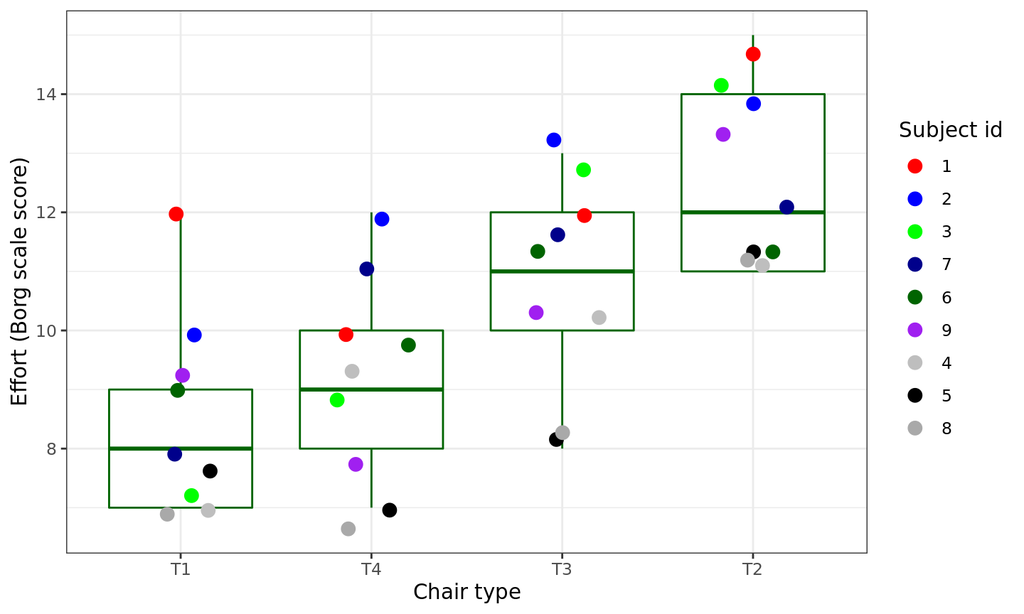

```r
colours <- c("red","blue", "green", "darkblue", "darkgreen", "purple", "grey", "black", "darkgrey")
set.seed(123)
plot_ergo <- ergoStool %>%
  ggplot(aes(x = reorder(Type, effort), y = effort)) +
  geom_boxplot(colour = "darkgreen", outlier.shape = NA) +
  geom_jitter(aes(colour = reorder(Subject, -effort)),
              width = 0.2, size = 3) +
  scale_colour_manual(values = colours) +
  ylab("Effort (Borg scale score)") +
  xlab("Chair type") +
  guides(colour=guide_legend(title="Subject id")) +
  theme_bw()
plot_ergo
```

## Mind the variability per subject, what do you see?

- Can you say something about within-subject variability (note ‘Minster Blue’)?
- Can you say something about between-subject variability (note ‘Mister Green’, vs ‘Mister Black’)?
- Which chair type takes, on average the biggest effort to arise from?

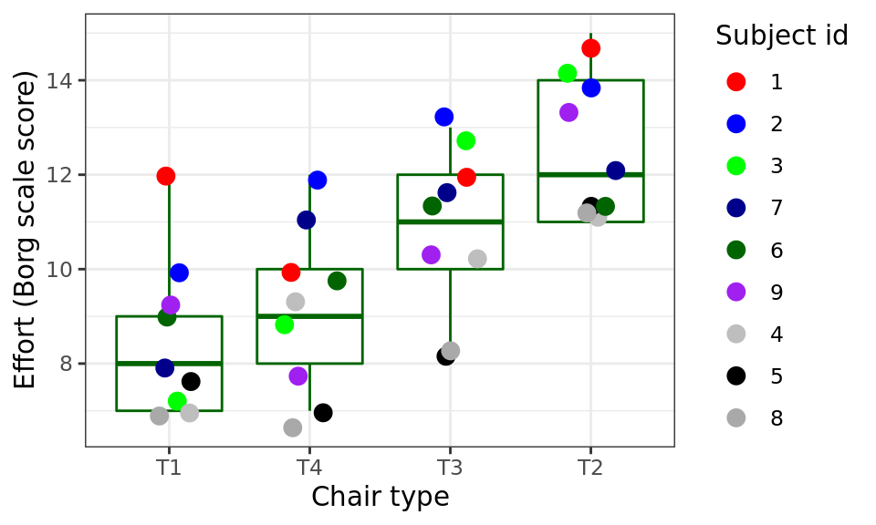

```r
plot_ergo
```

## The statistical questions

1. Which chair type takes, on average the biggest effort to arise from?
- Do individual (within subject) differences play a role in appointing a average score to a chair type?
- Does variability between subjects play a role in determining the ‘best’ chair type?

## The statistical model

Statistical models (in R) can be specified by a `model formula`. The left side of the formula is the dependent variable, the right side are the ‘predictors’. Here we include a `fixed` and a `random` term to the model (as is common for mixed-effects models)

```r
library(nlme)
```

```r
ergo_model <- lme(
  data = ergoStool, # the data to be used for the model
  fixed = effort ~ Type, # the dependent and fixed effects variables
  random = ~1 | Subject # observations for effort are assumed to be randomized over Subject
)
```

The `lme()` function is part of the [`{nlme}`](https://cran.r-project.org/web/packages/nlme/index.html) package for mixed effects modelling in R

Example reproduced from: [Pinheiro and Bates, 2000, *Mixed-Effects Models in S and S-PLUS*, Springer, New York.](https://cran.r-project.org/web/packages/nlme/index.html)

## The statistical results

```r
result <- ergo_model %>% summary()
result$tTable %>% as.data.frame() %>% knitr::kable()
```

|  | Value | Std.Error | DF | t-value | p-value |
| --- | --- | --- | --- | --- | --- |
| (Intercept) | 8.5555556 | 0.5760123 | 24 | 14.853079 | 0.0000000 |
| TypeT2 | 3.8888889 | 0.5186838 | 24 | 7.497610 | 0.0000001 |
| TypeT3 | 2.2222222 | 0.5186838 | 24 | 4.284348 | 0.0002563 |
| TypeT4 | 0.6666667 | 0.5186838 | 24 | 1.285305 | 0.2109512 |

## Model diagnostics

- Diagnostics of a fitted model is the most important step in a statistical analysis
- In most scientific papers the details are lacking
- Did the authors omit to perform this step? Or did they not report it?
- If you do not want to include it in your paper, put it in an appendix!

## Residuals

A residual plot shows the ‘residual’ error (‘unexplained variance’) after fitting the model. Under the Normality assumption standardized residuals should:

1. Be normally distributed around 0
2. Display no obvious ‘patters’
3. Should display overall equal ‘spread’ above and below 0 (‘assumption of equal variance’ [homoscedasticity])

## Residual plot

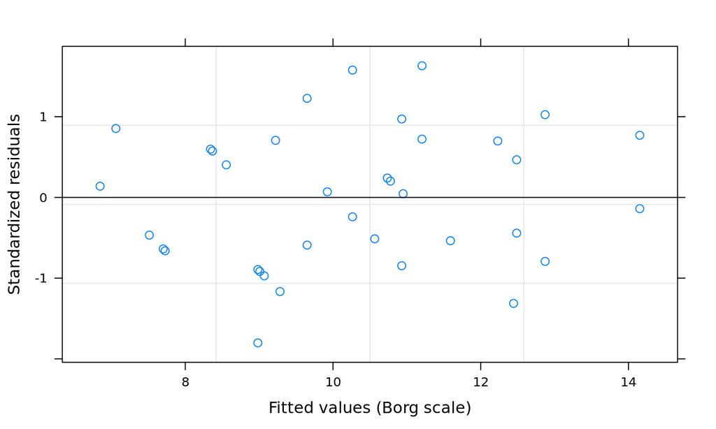

```r
plot(ergo_model) ## type = 'pearson' (standardized residuals)
```

## The conclusions in a plot

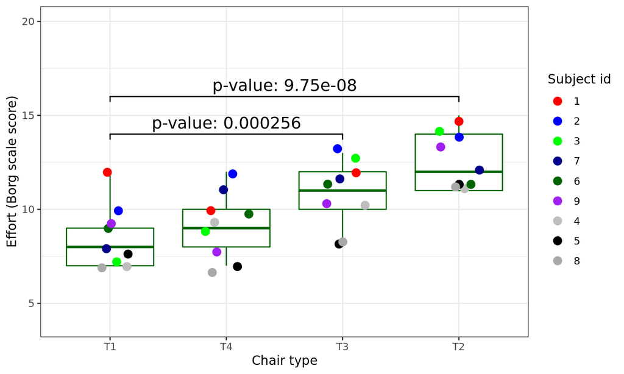

```r
# install.packages("ggsignif")
library(ggsignif)
p_values <- result$tTable %>% as.data.frame()
annotation_df <- data.frame(Type=c("T1", "T2"),
                            start=c("T1", "T1"),
                            end=c("T2", "T3"),
                            y=c(16, 14),
                            label=
                              paste("p-value:",
                              c(
                              formatC(
                                p_values$`p-value`[2], digits = 3),
                              formatC(
                                p_values$`p-value`[3], digits = 3)
                              )
                            )
                          )

set.seed(123)
ergoStool %>%
  ggplot(aes(x = reorder(Type, effort),
             y = effort)) +
  geom_boxplot(colour = "darkgreen",
               outlier.shape = NA) +
  geom_jitter(aes(
    colour = reorder(Subject, -effort)),
    width = 0.2,
    size = 3) +
  scale_colour_manual(
    values = c(
      "red", "blue","green",
      "darkblue", "darkgreen",
      "purple", "grey", "black",
      "darkgrey")) +
  ylab("Effort (Borg scale score)") +
  xlab("Chair type") +
  guides(colour=guide_legend(title="Subject id")) +
  ylim(c(4,20)) +
  geom_signif(
    data=annotation_df,
    aes(xmin=start,
    xmax=end,
    annotations=label,
    y_position=y),
    textsize = 5, vjust = -0.2,
    manual=TRUE) +
  theme_bw() -> plot_ergo
plot_ergo
```

## And Importantly…

– Coffee break –

## After the coffee break:

1. RStudio demo
2. Introduction to R (syntax & objects)

## Getting R & RStudio in the HU

- RStudio Server Virtual Machine
- Running on SURF infrastructure (Amsterdam data center)
- Request a server via the form on [ASK HU](https://askhu.sharepoint.hu.nl/informatie-items/Paginas/Data-analyse-omgeving-aanvragen.aspx)
- [User Documentation](https://datascience.hu.nl/)
- Onderzoeksupport Helpdesk
- [Use cases, themes, learning, discussions - PSG-DS](https://teams.microsoft.com/l/team/19%3ab94468b3341749c0a022a591de8a5e8d%40thread.tacv2/conversations?groupId=d54a13d1-19b8-4922-a8a6-96837e1470f6&tenantId=98932909-9a5a-4d18-ace4-7236b5b5e11d)

## RStudio demo

- The RStudio Windows (1-4)
- The Global Environment
- Global settings -> Rmd output / Theme
- Upload / Download files
- Shared folder
- Installing and searching R packages (Question: “Can anyone share a specific method of analysis in the chat?”)
- Help on packages and functions (`?` / `help()` / RStudio Help-panel / Vignettes)
- Plots
- Data import
- New files (R / Python etc…)
- Reformat Code
- RStudio Project
- Folder structure
- Git clone - get `staRters` course materials
- Creating a pull request / Contributing to the material (fixing a **tipo**)
- Shiny Apps [CoronaDash](https://datascience.hu.nl/shiny/r-starters/marc.teunis/CoronaDash/)